# Machine Learning: AllLife Bank Personal Loan Campaign

**Checking Performance on test data**

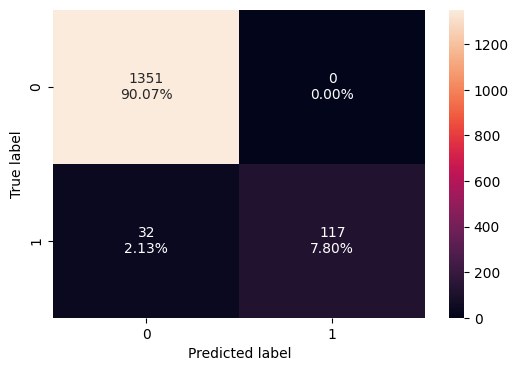

```python
confusion_matrix_sklearn(estimator, X_test, y_test)
```

```python
decision_tree_tune_perf_test = model_performance_classification_sklearn(estimator, X_test, y_test)
decision_tree_tune_perf_test
```

|  | Accuracy | Recall | Precision | F1 |
| --- | --- | --- | --- | --- |
| 0 | 0.978667 | 0.785235 | 1.0 | 0.879699 |

The model performs well on the test data with accuracy as 0.97, Recall 0.78, Precision 1.0 & F1-Score - 0.87

**Post Pruning (Cost-Complexity Pruning)**

The DecisionTreeClassifier includes parameters such as min_samples_leaf and max_depth to prevent overfitting. Additionally, cost complexity pruning is available to control tree size. This pruning technique uses the cost complexity parameter, ccp_alpha, where larger values result in more nodes being pruned. In this context, we demonstrate how ccp_alpha regularizes trees and guide how to select an appropriate ccp_alpha based on validation scores.

```python
clf = DecisionTreeClassifier(random_state=1)
path = clf.cost_complexity_pruning_path(X_train, y_train)
ccp_alphas, impurities = path.ccp_alphas, path.impurities
```

```python
pd.DataFrame(path)
```

|  | ccp_alphas | impurities |
| --- | --- | --- |
| 0 | 0.000000 | 0.000000 |
| 1 | 0.000186 | 0.001114 |
| 2 | 0.000214 | 0.001542 |
| 3 | 0.000242 | 0.002750 |
| 4 | 0.000250 | 0.003250 |
| 5 | 0.000268 | 0.004324 |
| 6 | 0.000272 | 0.004868 |
| 7 | 0.000276 | 0.005420 |
| 8 | 0.000381 | 0.005801 |
| 9 | 0.000527 | 0.006329 |
| 10 | 0.000625 | 0.006954 |
| 11 | 0.000700 | 0.007654 |
| 12 | 0.000769 | 0.010731 |
| 13 | 0.000882 | 0.014260 |
| 14 | 0.000889 | 0.015149 |
| 15 | 0.001026 | 0.017200 |
| 16 | 0.001305 | 0.018505 |
| 17 | 0.001647 | 0.020153 |
| 18 | 0.002333 | 0.022486 |
| 19 | 0.002407 | 0.024893 |
| 20 | 0.003294 | 0.028187 |
| 21 | 0.006473 | 0.034659 |
| 22 | 0.025146 | 0.084951 |
| 23 | 0.039216 | 0.124167 |
| 24 | 0.047088 | 0.171255 |

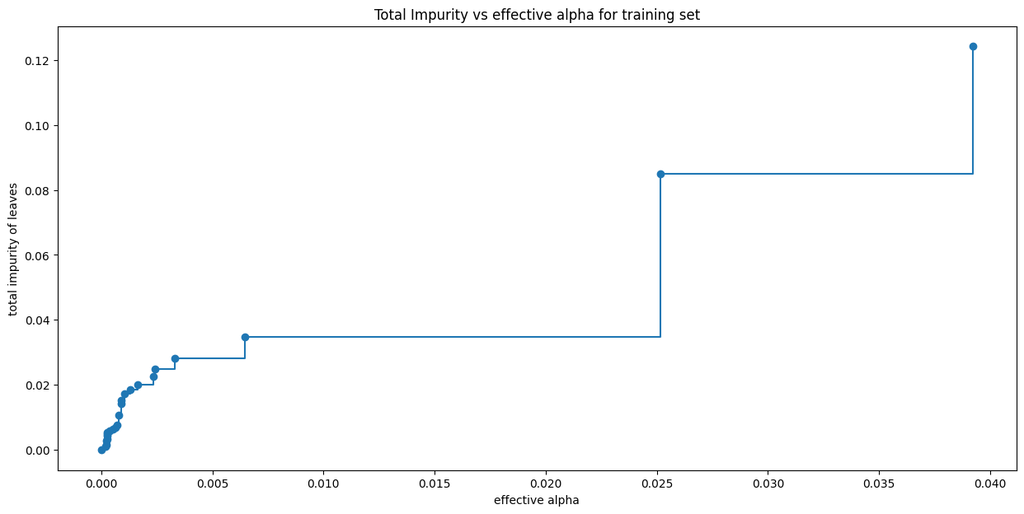

```python
# Let's Plot Alpha versus Impurities

fig, ax = plt.subplots(figsize=(15, 7))
ax.plot(ccp_alphas[:-1], impurities[:-1], marker="o", drawstyle="steps-post")
ax.set_xlabel("effective alpha")
ax.set_ylabel("total impurity of leaves")
ax.set_title("Total Impurity vs effective alpha for training set")
plt.show()
```

```python
clfs = []
for ccp_alpha in ccp_alphas:
    clf = DecisionTreeClassifier(
        random_state=1, ccp_alpha=ccp_alpha, class_weight={0:0.15,1:0.85}
    )
    clf.fit(X_train, y_train)
    clfs.append(clf)
print(
    "Number of nodes in the last tree is: {} with ccp_alpha: {}".format(
        clfs[-1].tree_.node_count, ccp_alphas[-1]
    )
)
```

```
Number of nodes in the last tree is: 3 with ccp_alpha: 0.04708834100596766
```

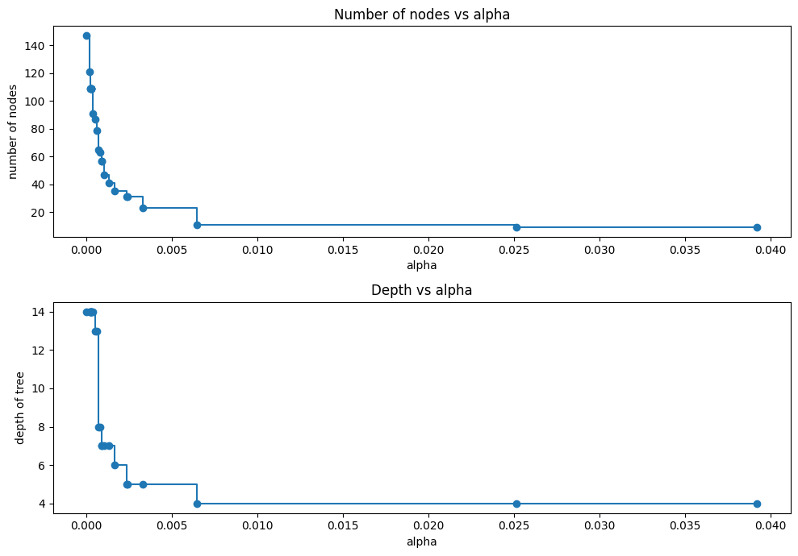

```python
clfs = clfs[:-1]
ccp_alphas = ccp_alphas[:-1]

node_counts = [clf.tree_.node_count for clf in clfs]
depth = [clf.tree_.max_depth for clf in clfs]
fig, ax = plt.subplots(2, 1, figsize=(10, 7))
ax[0].plot(ccp_alphas, node_counts, marker="o", drawstyle="steps-post")
ax[0].set_xlabel("alpha")
ax[0].set_ylabel("number of nodes")
ax[0].set_title("Number of nodes vs alpha")
ax[1].plot(ccp_alphas, depth, marker="o", drawstyle="steps-post")
ax[1].set_xlabel("alpha")
ax[1].set_ylabel("depth of tree")
ax[1].set_title("Depth vs alpha")
fig.tight_layout()
```

Recall Vs Alpha for training and testing sets

```python
recall_train = []
for clf in clfs:
    pred_train = clf.predict(X_train)
    values_train = recall_score(y_train, pred_train)
    recall_train.append(values_train)
```

```python
recall_test = []
for clf in clfs:
    pred_test = clf.predict(X_test)
    values_test = recall_score(y_test, pred_test)
    recall_test.append(values_test)
```

```python
train_scores = [clf.score(X_train, y_train) for clf in clfs]
test_scores = [clf.score(X_test, y_test) for clf in clfs]
```

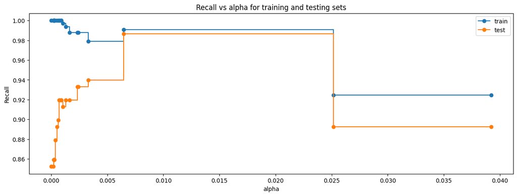

```python
fig, ax = plt.subplots(figsize=(15, 5))
ax.set_xlabel("alpha")
ax.set_ylabel("Recall")
ax.set_title("Recall vs alpha for training and testing sets")
ax.plot(
    ccp_alphas, recall_train, marker="o", label="train", drawstyle="steps-post",
)
ax.plot(ccp_alphas, recall_test, marker="o", label="test", drawstyle="steps-post")
ax.legend()
plt.show()
```

```python
# creating the model where we get highest train and test recall
index_best_model = np.argmax(recall_test)
best_model = clfs[index_best_model]
print(best_model)
```

```
DecisionTreeClassifier(ccp_alpha=0.006472814718223811,
                       class_weight={0: 0.15, 1: 0.85}, random_state=1)
```

```python
estimator_2 = DecisionTreeClassifier(
    ccp_alpha=0.006, class_weight={0: 0.15, 1: 0.85}, random_state=1
)
estimator_2.fit(X_train, y_train)
```

```
DecisionTreeClassifier(ccp_alpha=0.006, class_weight={0: 0.15, 1: 0.85},
                       random_state=1)
```

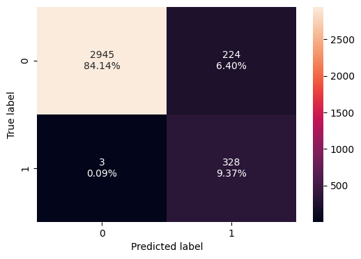

```python
confusion_matrix_sklearn(estimator_2, X_train, y_train)
```

```python
decision_tree_tune_post_train = model_performance_classification_sklearn(estimator_2,X_train,y_train) ## Complete the code to check performance on train data
decision_tree_tune_post_train
```

|  | Accuracy | Recall | Precision | F1 |
| --- | --- | --- | --- | --- |
| 0 | 0.935143 | 0.990937 | 0.594203 | 0.742922 |

**Visualizing the Decision Tree**

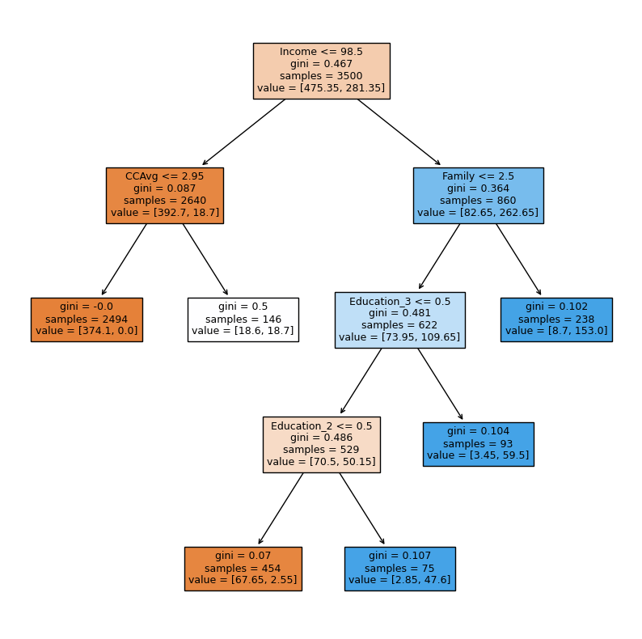

```python
plt.figure(figsize=(10, 10))
out = tree.plot_tree(
    estimator_2,
    feature_names=feature_names,
    filled=True,
    fontsize=9,
    node_ids=False,
    class_names=None,
)
# below code will add arrows to the decision tree split if they are missing
for o in out:
    arrow = o.arrow_patch
    if arrow is not None:
        arrow.set_edgecolor("black")
        arrow.set_linewidth(1)
plt.show()
```

```python
# Text report showing the rules of a decision tree -

print(tree.export_text(estimator_2, feature_names=feature_names, show_weights=True))
```

```
|--- Income <= 98.50
|   |--- CCAvg <= 2.95
|   |   |--- weights: [374.10, 0.00] class: 0
|   |--- CCAvg >  2.95
|   |   |--- weights: [18.60, 18.70] class: 1
|--- Income >  98.50
|   |--- Family <= 2.50
|   |   |--- Education_3 <= 0.50
|   |   |   |--- Education_2 <= 0.50
|   |   |   |   |--- weights: [67.65, 2.55] class: 0
|   |   |   |--- Education_2 >  0.50
|   |   |   |   |--- weights: [2.85, 47.60] class: 1
|   |   |--- Education_3 >  0.50
|   |   |   |--- weights: [3.45, 59.50] class: 1
|   |--- Family >  2.50
|   |   |--- weights: [8.70, 153.00] class: 1
```

```python
# importance of features in the tree building ( The importance of a feature is computed as the
# (normalized) total reduction of the criterion brought by that feature. It is also known as the Gini importance )

print(
    pd.DataFrame(
        estimator_2.feature_importances_, columns=["Imp"], index=X_train.columns
    ).sort_values(by="Imp", ascending=False)
)
```

```
                         Imp
Income              0.636860
Education_2         0.160224
Education_3         0.076930
Family              0.069445
CCAvg               0.056541
ZIPCode_92          0.000000
ZIPCode_96          0.000000
ZIPCode_95          0.000000
ZIPCode_94          0.000000
ZIPCode_93          0.000000
Age                 0.000000
ZIPCode_91          0.000000
Experience          0.000000
Online              0.000000
CD_Account          0.000000
Securities_Account  0.000000
Mortgage            0.000000
CreditCard          0.000000
```

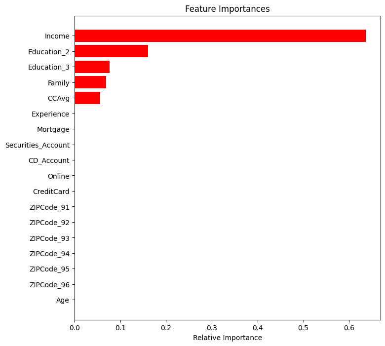

```python
importances = estimator_2.feature_importances_
indices = np.argsort(importances)

plt.figure(figsize=(8, 8))
plt.title("Feature Importances")
plt.barh(range(len(indices)), importances[indices], color="red", align="center")
plt.yticks(range(len(indices)), [feature_names[i] for i in indices])
plt.xlabel("Relative Importance")
plt.show()
```

**Checking Performance on test data**

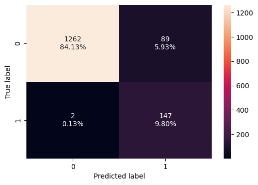

```python
confusion_matrix_sklearn(estimator_2, X_test,y_test)
```

```python
decision_tree_tune_post_test = model_performance_classification_sklearn(estimator_2, X_test, y_test)
decision_tree_tune_post_test
```

|  | Accuracy | Recall | Precision | F1 |
| --- | --- | --- | --- | --- |
| 0 | 0.939333 | 0.986577 | 0.622881 | 0.763636 |

```python
decision_tree_post_test = model_performance_classification_sklearn(
    best_model, X_test, y_test
)
decision_tree_post_test
```

|  | Accuracy | Recall | Precision | F1 |
| --- | --- | --- | --- | --- |
| 0 | 0.939333 | 0.986577 | 0.622881 | 0.763636 |

## Model Comparison and Final Model Selection

```python
# training performance comparison

models_train_comp_df = pd.concat(
    [decision_tree_perf_train.T, decision_tree_tune_perf_train.T, decision_tree_tune_post_train.T], axis=1,
)
models_train_comp_df.columns = ["Decision Tree sklearn", "Decision Tree (Pre-Pruning)", "Decision Tree (Post-Pruning)"]
print("Training performance comparison:")
models_train_comp_df
```

```
Training performance comparison:
```

|  | Decision Tree sklearn | Decision Tree (Pre-Pruning) | Decision Tree (Post-Pruning) |
| --- | --- | --- | --- |
| Accuracy | 1.0 | 0.987714 | 0.935143 |
| Recall | 1.0 | 0.873112 | 0.990937 |
| Precision | 1.0 | 0.996552 | 0.594203 |
| F1 | 1.0 | 0.930757 | 0.742922 |

```python
# testing performance comparison

models_test_comp_df = pd.concat(
    [decision_tree_perf_test.T, decision_tree_tune_perf_test.T, decision_tree_tune_post_test.T], axis=1,
)
models_test_comp_df.columns = ["Decision Tree sklearn", "Decision Tree (Pre-Pruning)", "Decision Tree (Post-Pruning)",]
print("Test performance comparison:")
models_test_comp_df
```

```
Test performance comparison:
```

|  | Decision Tree sklearn | Decision Tree (Pre-Pruning) | Decision Tree (Post-Pruning) |
| --- | --- | --- | --- |
| Accuracy | 0.986000 | 0.978667 | 0.939333 |
| Recall | 0.906040 | 0.785235 | 0.986577 |
| Precision | 0.950704 | 1.000000 | 0.622881 |
| F1 | 0.927835 | 0.879699 | 0.763636 |

Running the model without pre/post pruning gives a high score, which is expected due to the overfitting nature of decision trees.

We can conclude that the post-pruned model of the decision tree performs best, as it provides the highest recall scores.

**Hyper parameter Value** ccp_alpha 0.006

## Actionable Insights and Business Recommendations

**Insights**

To provide an accurate prediction of customers who will accept a personal loan, we recommend the post-pruned decision tree model to the business.

The feature importances are as follows:

**Income:** An increase in income leads to a higher likelihood of a customer accepting a loan.

**Education_2:** Customers with a graduate level of education are more willing to accept a loan.

**Education_3:** Customers with an advanced/professional level of education are more willing to accept a loan.

**CCAvg:** Higher average monthly spending on credit cards increases the chances of a customer accepting a loan.

**Family:** Larger family size correlates with a higher likelihood of loan acceptance.

**Recommendations/Take-Aways for the Marketing Team**

**Target High-Income Segments:**

- Focus marketing efforts on customers with higher income levels, as they are more likely to accept personal loans.
- Customize loan offers with attractive terms for high-income individuals.

**Educational Segmentation:**

- Develop targeted campaigns for customers with graduate and advanced/professional education levels.
- Highlight loan benefits that align with the financial goals and needs of educated customers.

**Credit Card Usage Insights:**

- Identify customers with higher average monthly spending on credit cards and target them with personalized loan offers.
- Emphasize how personal loans can help manage and consolidate credit card debt more effectively.

**Family-Oriented Offers:**

- Create marketing strategies that appeal to larger families, highlighting the benefits of loans for family-related expenses such as home improvements, education, or vacations.
- Promote special loan products designed for customers with larger families.

**Data-Driven Marketing:**

- Use the insights from the decision tree model to refine customer segmentation and target the most promising segments.
- Continuously monitor and analyze customer data to adjust marketing strategies based on changing customer profiles and behaviors.

**Customer Education:**

- Educate potential customers about the advantages of taking personal loans, especially those in the identified high-likelihood segments.
- Provide clear, informative content on how personal loans can help achieve financial goals.

**Feedback and Improvement:**

- Collect feedback from customers who accept or decline loan offers to understand their motivations and barriers.
- Use this feedback to further refine the decision tree model and improve marketing approaches.